# SD Single Cell Genotyping Data Reduction

*****Click on the gear above and choose: “Chunk Output in Console” before proceeding*****

## Initialize libraries and Directory setup

Sets up the directory structure for where to look for data, and where to save results.  
This assumes that the data structure is what is in the github repo and what is produced by the ImageJ macros.

## Run Metadata

```r
arrayList <- c("A1", "A2", "A3")
ampFluor <- "FAM"; wtFluor <- "Cy5"; mutFluor <- "HEX"
fluorList <- c(ampFluor, wtFluor, mutFluor)
```

# Read in and Melt Raw Data

Read in the individual csv’s for each fluorphore, via searching the input directory for filenames containing the names of the fluors used in this experiment. This generates a melted data frame containing the concatenated data sets from each fluorophore.

```r
fileNames <- list.files(path = fluorInput, pattern = "*.csv", full.names = TRUE)
dataList <- lapply(fluorList, function(x)
    {read.csv(file = fileNames[grep(x, fileNames)], stringsAsFactors = FALSE)})
names(dataList) <- fluorList
dataList <- lapply(dataList, function(x) {colnames(x)[1] <- "Well";x})
allFluors <- melt(dataList, id=colnames(dataList[[1]]))
colnames(allFluors)[length(colnames(allFluors))] <- "Fluor"
names(allFluors)[names(allFluors) == "X.Area"] <- "Area"

rm(dataList)
```

## Calculate AID

Note: Area is divided by Max % Fill per ROI, which has already been calculated for this master/array design as 9 pixels by 17 pixels, and ROI grid is 400 pixels, so the max % Fill per ROI is 38.25%

```r
wellTotal <- 1024  # Total number of wells in a single array
allFluors$Array[allFluors$Well <= wellTotal] <- "A1"
allFluors$Array[allFluors$Well >= wellTotal+1 & allFluors$Well <= 2*wellTotal] <- "A2"
allFluors$Array[allFluors$Well > 2*wellTotal] <- "A3"

allFluors$AID <- allFluors$IntDen/(allFluors$Area/38.25)
allFluors$Fluor <- factor(allFluors$Fluor, levels = fluorList)
allFluors$Array <- factor(allFluors$Array)
allFluors <- allFluors %>% mutate(Template = "OCI-AML3")
```

## Data formatting to generate a “spread” format for further analysis.

Uses the area calculated in the ampFluor channel as the true Area from here on out.

```r
procData <- allFluors[c("Well", "Fluor", "Array", "AID")]
ampArea <- allFluors %>% filter(Fluor == ampFluor) %>% select(Well, Area, Array, Template)

wideForm <- procData %>% group_by(Array) %>% spread(Fluor, AID)
colnames(wideForm)[which(grepl(ampFluor, colnames(wideForm)))] <- "ampFluor"
colnames(wideForm)[which(grepl(wtFluor, colnames(wideForm)))] <- "wtFluor"
colnames(wideForm)[which(grepl(mutFluor, colnames(wideForm)))] <- "mutFluor"

primeTime <- merge(ampArea, wideForm)
primeTime <- primeTime[order(primeTime$Well),]
primeTime$ArrayRow <- rep(1:16, each = 64)
primeTime$ArrayCol <- seq(1:64)

rm(procData, ampArea, wideForm)
```

## Fill Thresholding

Plot data as a function of area in order to visualize the area threshold for identifying which wells “filled” and which did not prior to downstream gating.

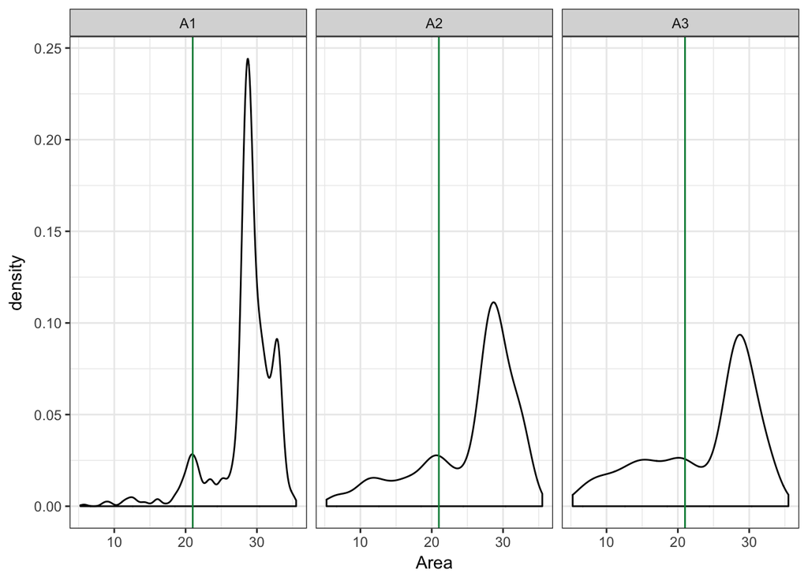

```r
tArea <- 21
ggplot(data = primeTime %>% filter(Area > 5), aes(x=Area)) +
    geom_density() + facet_grid(. ~ Array) +
    geom_vline(xintercept = tArea, color = "springgreen4") +
    theme_bw()
```

Apply one area threshold to the data frame for all arrays and generate a new “ruleThemAll”.

```r
ruleThemAll <- primeTime %>% group_by(Array) %>% mutate(Filled = Area > tArea)
```

## HEX Correction and Thresholding

Set the constant used to correct for FAM bleed-through in the HEX channel. This value was calcuated based on the average of several runs of mutant plasmids.

```r
avgHEXSlope <- 0.46
#snowCone <- mutate(ruleThemAll, runID = "OCI-AML3 Cells")

snowCone <- mutate(ruleThemAll, mutFluorAdj = mutFluor - avgHEXSlope*ampFluor)
#snowCone$mutFluorAdj <- NA
```

Required for thresholding: Calculate max of density curve

```r
#set approximate range of negative wells to get more accurate denisity curve
AmpMax    <- 1100000
MutMax    <- 2000000
WtMax     <- 1500000
MutAdjMax <- 1000000
WtAdjMax  <- 1500000

#rearrange columns to make gather work
snowCone <- select(snowCone, Well, Array, Area, Template, ampFluor, wtFluor, mutFluor, mutFluorAdj, ArrayRow, ArrayCol, Filled)

#function to find the max density
Peak <- function(X) {
      Y = density(X, na.rm = TRUE);
      Z = data.frame(Intensity = Y$x, Density = Y$y);
    return(Z$Intensity[which.max(Z$Density)])
}

#make a table with max AID's for each Fluor
snowPeaks <- snowCone %>% filter(ampFluor < AmpMax, mutFluor < MutMax, wtFluor < WtMax) %>% gather(Fluor, AID, ampFluor:mutFluor) %>%
          filter(Filled == TRUE) %>%
          group_by(Array, Fluor) %>%
          do(data.frame(maxAID = Peak(.$AID)))

mutAdjPeaks <- snowCone %>% gather(Fluor, AID, ampFluor:mutFluorAdj) %>%
          filter(Filled == TRUE, Fluor == "mutFluorAdj", AID < MutAdjMax) %>%
          group_by(Array, Fluor) %>%
          do(data.frame(maxAID = Peak(.$AID)))

snowPeaksAdj <- bind_rows(snowPeaks, mutAdjPeaks)
```

Calculate thresholds using previously determined maxSD of negative controls

```r
xsigamp <- 3
xsigmut <- 6
xsigwt <- 5

PSwapampSD    <- 41753*xsigamp
PSwapwtSD     <- 29937*xsigwt
PSwapmutAdjSD <- 52998*xsigmut

#Add thresholds to snowPeaksAdj
snowDrift <- snowPeaksAdj %>% mutate(Threshold = if_else( Fluor == "ampFluor", maxAID + PSwapampSD,
                                                  if_else( Fluor == "wtFluor", maxAID + PSwapwtSD,
                                                  if_else( Fluor == "mutFluorAdj", maxAID + PSwapmutAdjSD,
                                                          0))))

#Add this threshold to the df with all the AID's
snowDrift1 <- snowDrift %>% select(Array, Fluor, Threshold) %>% spread(Fluor, Threshold) %>% select(Array, ampThresh = ampFluor, mutThresh = mutFluor, mutAdjThresh = mutFluorAdj, wtThresh = wtFluor)

snowCone1 <- left_join(snowCone, snowDrift1, by = c("Array"))
```

Visualize amplification thresholds to spot errors

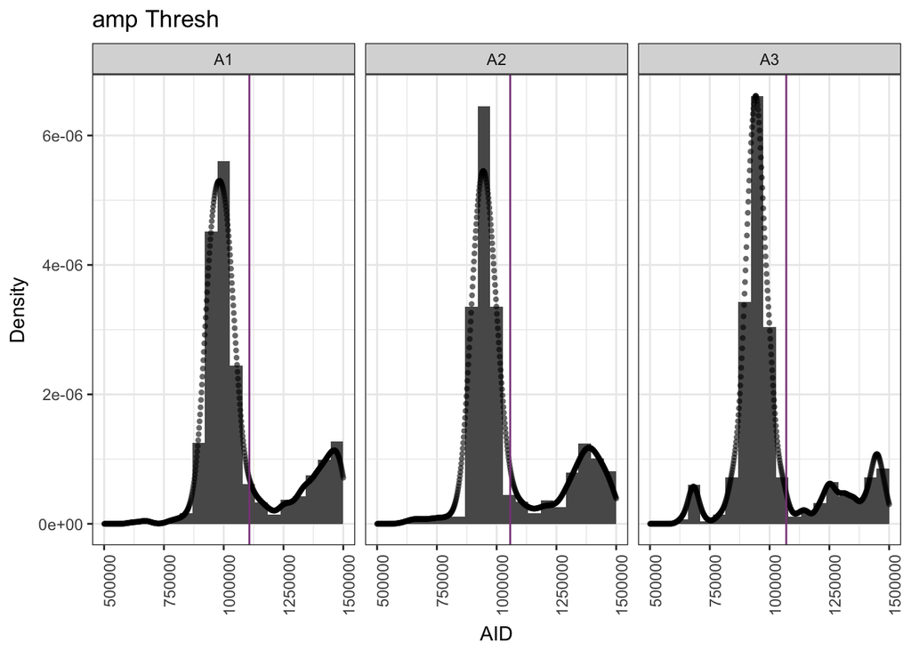

```r
ampThreshPlot <- ggplot(snowCone1 %>% filter(Filled == TRUE), aes(x=ampFluor)) +
                            geom_histogram(aes(x = ampFluor, y = ..density..), bins = 20) +
                            geom_point(stat = "density", alpha = 0.6, stroke = 0) +
                            geom_vline(aes(xintercept = ampThresh), color = "orchid4") +
                            xlim(500000, 1500000) +
                            xlab("AID") + ylab("Density") +
                            facet_grid(.~ Array) +
                            ggtitle("amp Thresh") +
                            theme_bw() +
                            theme(strip.text.y = element_blank(), axis.text.x = element_text(angle=90, hjust=1))
ampThreshPlot
```

View scatter plot of mutant fluorophore vs wild-type fluorophore intensity

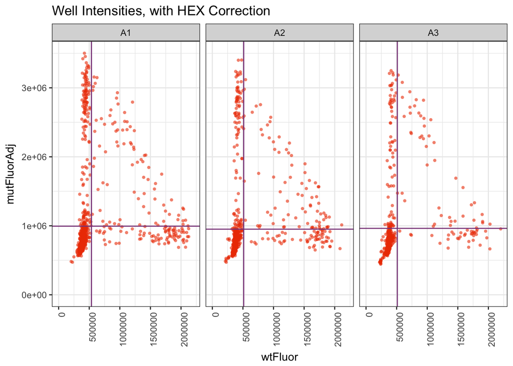

```r
mutAdj_vs_wt_Scatter <- ggplot(snowCone1 %>% filter(Filled == TRUE),
            aes(x=wtFluor, y=mutFluorAdj)) +
            geom_point(alpha = 0.6, stroke = 0, color = "orangered2") +
            geom_vline(aes(xintercept = wtThresh), color = "orchid4") +
            geom_hline(aes(yintercept = mutAdjThresh), color = "orchid4") +
            xlim(0,max(snowCone1$wtFluor, na.rm = TRUE)) +
            ylim(0,max(snowCone1$mutFluorAdj, na.rm = TRUE)) +
            labs(x = "wtFluor", y = "mutFluorAdj") +
            facet_grid(. ~ Array) +
            ggtitle("Well Intensities, with HEX Correction") +
            theme_bw() +
            theme(strip.text.y = element_blank(), axis.text.x = element_text(angle=90, hjust=1))
mutAdj_vs_wt_Scatter
```

Save a .jpeg of the mut vs. wt scatter plots

```r
ggsave(mutAdj_vs_wt_Scatter, filename = paste0(output,"mutAdj_vs_wt_Scatter.jpeg"))
```

Determine amplification positivity for each well

```r
snowCone2 <- mutate(snowCone1, AmpPos = FALSE)

snowCone2 <- snowCone2 %>% mutate(AmpPos = ampFluor >= ampThresh)

snowCone2$AmpPos <- as.factor(snowCone2$AmpPos)
```

Determine Zygosities in the individual arrays

```r
snowCone3 <- mutate(snowCone2, Zygosity = "UNCALLED")

snowCone3$wtFluor[is.na(snowCone3$wtFluor)] <- 0
snowCone3$mutFluor[is.na(snowCone3$mutFluor)] <- 0
snowCone3$mutFluorAdj[is.na(snowCone3$mutFluorAdj)] <- 0
snowCone3$ampFluor[is.na(snowCone3$ampFluor)] <- 0


snowCone3 <- snowCone3 %>% mutate(Zygosity = replace(Zygosity, Filled == TRUE & AmpPos == TRUE  &
                     wtFluor >= wtThresh & mutFluorAdj < mutAdjThresh, "WT"))

snowCone3 <- snowCone3 %>% mutate(Zygosity = replace(Zygosity, Filled == TRUE & AmpPos == TRUE  &
                     wtFluor < wtThresh & mutFluorAdj >= mutAdjThresh, "MUT"))

snowCone3 <- snowCone3 %>% mutate(Zygosity = replace(Zygosity, Filled == TRUE & AmpPos == TRUE  &
                     wtFluor >= wtThresh & mutFluorAdj >= mutAdjThresh, "HET"))

snowCone3$Zygosity <- factor(snowCone3$Zygosity, levels = c("WT", "HET", "MUT","UNCALLED"))

snowCone3 <- mutate(snowCone3, FluorQC = factor("ThisIsFine", levels = c("wtFluor", "mutFluor", "Both", "AmpOnly", "Negative", "ThisIsFine")))


snowCone3 <- snowCone3 %>% mutate(FluorQC = replace(FluorQC, Filled == TRUE & AmpPos == FALSE  &
                     wtFluor >= wtThresh & mutFluorAdj < mutAdjThresh, "wtFluor"))

snowCone3 <- snowCone3 %>% mutate(FluorQC = replace(FluorQC, Filled == TRUE & AmpPos == FALSE  &
                     wtFluor < wtThresh & mutFluorAdj >= mutAdjThresh, "mutFluor"))

snowCone3 <- snowCone3 %>% mutate(FluorQC = replace(FluorQC, Filled == TRUE & AmpPos == FALSE &
                     wtFluor >= wtThresh & mutFluorAdj >= mutAdjThresh, "Both"))

snowCone3 <- snowCone3 %>% mutate(FluorQC = replace(FluorQC, Filled == TRUE & AmpPos == TRUE &
                     wtFluor < wtThresh & mutFluorAdj < mutAdjThresh, "AmpOnly"))

snowCone3 <- snowCone3 %>% mutate(FluorQC = replace(FluorQC, Filled == TRUE & AmpPos == FALSE &
                     wtFluor < wtThresh & mutFluorAdj < mutAdjThresh, "Negative"))
```

## Plot Zygosity Results

Plot mut vs. wt with Zygosity

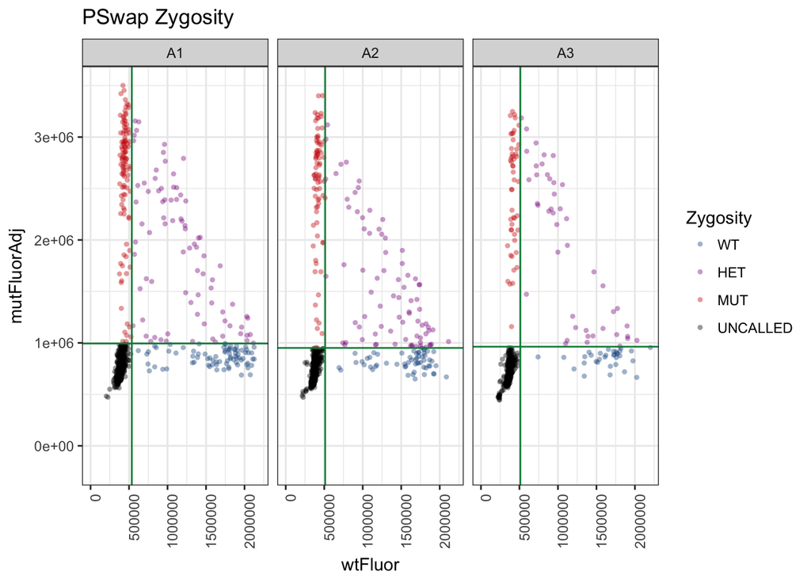

```r
FinalZygosity_PSwap <- ggplot(snowCone3 %>% filter(Filled ==TRUE, AmpPos == TRUE | FluorQC == "Negative"),
            aes(x=wtFluor, y=mutFluorAdj)) +
            geom_point(aes(color = Zygosity),alpha = 0.4, stroke = 0) +
            geom_vline(aes(xintercept = wtThresh), color = "springgreen4") +
            geom_hline(aes(yintercept = mutAdjThresh), color = "springgreen4") +
        scale_color_manual(values = c("dodgerblue4","magenta4", "red3", "black"), limits = levels(snowCone3$Zygosity)) +
            xlim(0,max(snowCone3$wtFluor, na.rm = TRUE)) +
            ylim(-200000,max(snowCone3$mutFluorAdj, na.rm = TRUE)) +
            labs(x = "wtFluor", y = "mutFluorAdj") +
            facet_grid(. ~ Array) +
            ggtitle("PSwap Zygosity") +
            theme_bw() +
            theme(axis.text.x = element_text(angle=90, hjust=1), strip.text.y = element_text(size = 7, angle = 0))
FinalZygosity_PSwap
```

```r
ggsave(FinalZygosity_PSwap, filename = paste0(output, "FinalZygosity_PSwap.jpeg"))
```

## Cell Calculations

Read In Cell Data

```r
filenames <- list.files(path = cellInput, pattern = ".csv", full.names = T)
images <- as.numeric(str_sub(gsub(".csv", "", filenames), -2,-1))
cellData <- lapply(filenames, function(x) read.csv(x, header = T))
names(cellData) <- images
cellMelt <- melt(cellData, id = colnames(cellData[[1]]))
colnames(cellMelt) <- c("imageWell", "cellCount", "imageId")
cellMelt$ROIorder <- seq(1:3072)

lookup <- data.frame(ROIorder = 1:3072)
lookup$ArrayCol <- rep(c(rep(1:11, len = 88), rep(12:22, len = 88),
                         rep(23:33, len = 88), rep(34:44, len = 88),
                         rep(45:55, len = 88), rep(56:64, len = 144),
                         rep(45:55, len = 88), rep(34:44, len = 88),
                         rep(23:33, len = 88), rep(12:22, len = 88),
                         rep(1:11, len = 88)), 3)
lookup$ArrayRow <- rep(c(rep(1:8, each = 11, len = 440),
                         rep(1:8, each = 9),rep(9:16, each = 9),
                         rep(9:16, each = 11, len = 440)),3)
lookup$estImageId <- c(rep(1:5, each = 88), rep(6:7, each = 72),
                       rep(8:17, each = 88), rep(18:19, each = 72),
                       rep(20:29, each = 88), rep(30:31, each = 72),
                       rep(32:36, each = 88))
lookup$Array <- rep(c("A1", "A2", "A3"), each = 1024)
lookup <- arrange(lookup, Array, ArrayRow, ArrayCol)
lookup$Well <- seq(1:3072)
fullMergeData <- join(lookup, cellMelt, by = "ROIorder", type = "left")
cellsReadyToRoll <- select(fullMergeData, Well, cellCount)
snowCone4 <- left_join(snowCone3, cellsReadyToRoll, by = c("Well"))
```

View the zygosities of the single cells per each array

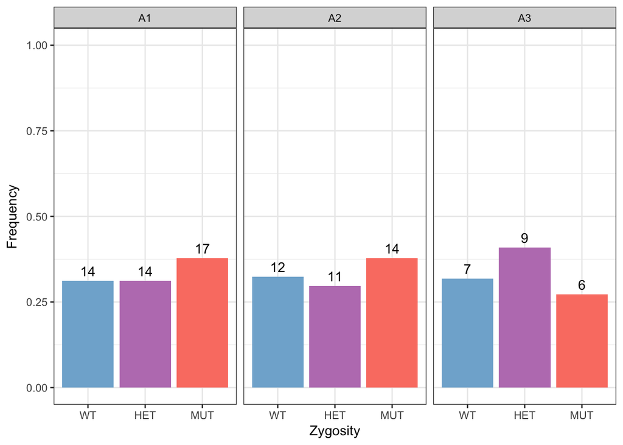

```r
set1 <- brewer.pal(n = 9, "Set1")
set3 <- brewer.pal(n = 12, "Set3")
zygcolors <- c(set3[5], set3[10], set3[4], "black", "white")

zygBarPlot <- ggplot(data = snowCone4 %>% filter(Zygosity != "UNCALLED" & cellCount == 1),
                     aes(x = Zygosity, fill = Zygosity, group = Array), color = "black") +
                      geom_bar(aes(y = ..prop.., fill = factor(..x..))) +
                      ylim(0, 1) +
                      scale_fill_manual(values = zygcolors) + theme_bw() +
                      geom_text(aes(label = ..count.., y = ..prop..), stat = "count", vjust = -0.5) +
                      labs(x = "Zygosity", y = "Frequency") +
                      scale_x_discrete(limits=c("WT", "HET", "MUT")) +
                      theme(legend.position = "none") +
                      facet_grid(. ~ Array) +
                      theme(strip.text.y = element_text(size = 7, angle = 0))
zygBarPlot
```

Save the zygosity plot

```r
ggsave(paste0(output, "zygBarPlot-singleCells.jpg"),
       zygBarPlot,
       width = 6, height = 6)
```

## Failure rate calculations

```r
failureData <- snowCone4 %>% group_by( Array, Template) %>%
    summarise(FalsePositives = n_distinct(which(Filled == TRUE & AmpPos == TRUE & cellCount == 0)),
              FalseNegatives = n_distinct(which(Filled == TRUE & AmpPos == FALSE & cellCount == 1)),
              TruePositives = n_distinct(which(Filled == TRUE & AmpPos == TRUE & cellCount == 1)),
              TrueNegatives = n_distinct(which(Filled == TRUE & AmpPos == FALSE & cellCount == 0)),
              DoubletPlus = n_distinct(which(Filled == TRUE & cellCount > 1)),
              EmptyWells = n_distinct(which(Filled == FALSE)),
              FDR = FalsePositives/(FalsePositives + TruePositives),
              FPR = FalsePositives/(FalsePositives + TrueNegatives),
              FNR = FalseNegatives/(FalseNegatives + TruePositives)
              )
```

View stacked bar plot of failure data

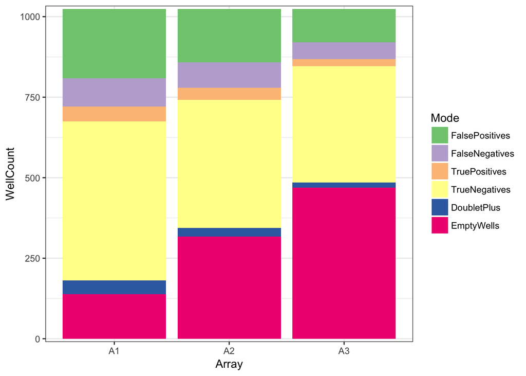

```r
failColors <- brewer.pal(6, "Accent")
failurePlotCounts <- melt(failureData %>% select(-c(FDR, FPR, FNR)), variable.name = "Mode", value.name = "WellCount")
failurePlot <- ggplot(data = failurePlotCounts) +
  geom_bar(aes(x = Array, y = WellCount, fill = Mode), stat = "identity") +
  scale_fill_manual(values = failColors) +
  scale_y_continuous(expand = c(0, 10)) +
  theme_bw()
failurePlot
```

save plot

```r
ggsave(paste0(output, "failurePlot.jpg"),
       failurePlot,
       width = 6, height = 6)
```

save csv

```r
write.csv(failureData, file = paste0(output,"failureRateResults.csv"), row.names = F)
```

## Poisson Distribution calculations

```r
experimentalLambda <- snowCone4 %>% group_by(Array,Template) %>%
    summarise(TotalCounts =   n_distinct(which(Filled == TRUE)),
              ZeroCells =     n_distinct(which(Filled == TRUE & cellCount == 0)),
              OneCell =       n_distinct(which(Filled == TRUE & cellCount == 1)),
              DoubletPlus =   n_distinct(which(Filled == TRUE & cellCount > 1)),
              ExpLambda =    -log(ZeroCells/TotalCounts),
              PredSingles =  TotalCounts*ExpLambda*exp(-ExpLambda)/1,
              PredDoubPlus = TotalCounts - ZeroCells - PredSingles
              )
```

View stacked barplot of cell counts

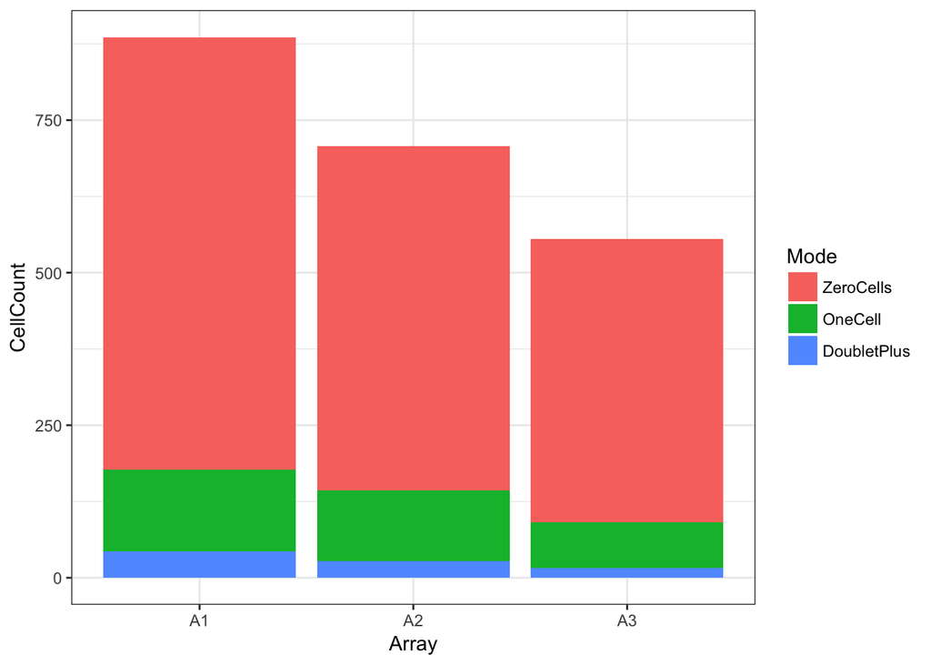

```r
cellNumPlot <- melt(experimentalLambda %>% select(Array, ZeroCells, OneCell, DoubletPlus), variable.name = "Mode", value.name = "CellCount")
CellCountPlot <- ggplot(data = cellNumPlot) +
  geom_bar(aes(x = Array, y = CellCount, fill = Mode), stat = "identity") +
  theme_bw()
CellCountPlot
```

Compare estimated and experimental zero/single/doublet+ counts, per array

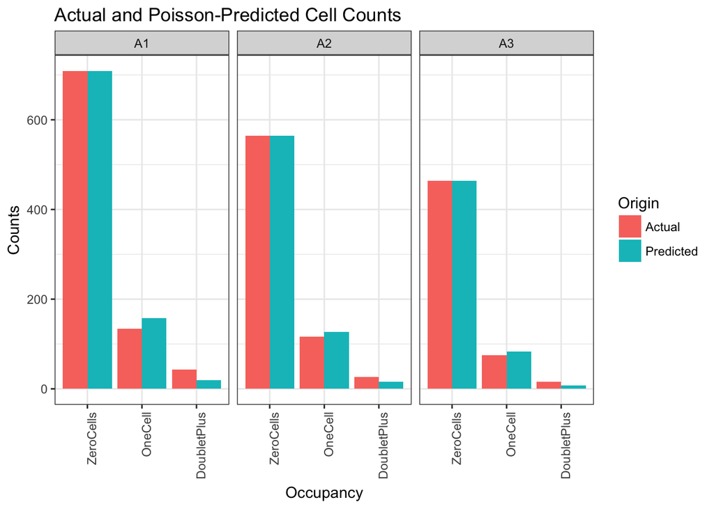

```r
PoissonTest <- experimentalLambda %>% gather("Occupancy", "Counts", ZeroCells:DoubletPlus) %>% select(Array:ExpLambda, Occupancy, Counts) %>% mutate(Origin = "Actual")
PoissonTest2 <- experimentalLambda %>% mutate(PredZero = ZeroCells) %>% select(Array:TotalCounts, ExpLambda, "OneCell"= PredSingles, "DoubletPlus" = PredDoubPlus, "ZeroCells" = PredZero) %>% gather("Occupancy", "Counts", OneCell:ZeroCells) %>% mutate(Origin = "Predicted")
PoissonFull <- PoissonTest %>% bind_rows(PoissonTest2)

PoissonFit <- ggplot(data = PoissonFull, aes(x = Occupancy, y = Counts, fill = Origin)) +
  geom_bar(stat = "identity", position = position_dodge()) +
  scale_x_discrete(limits=c("ZeroCells", "OneCell", "DoubletPlus")) +
  facet_grid(.~ Array) +
  ggtitle("Actual and Poisson-Predicted Cell Counts") +
  theme_bw() +
  theme(axis.text.x = element_text(angle=90, hjust=1), strip.text.y = element_text(size = 7, angle = 0))
PoissonFit
```

Compare estimated and experimental zero/single/doublet+ counts, all data added together

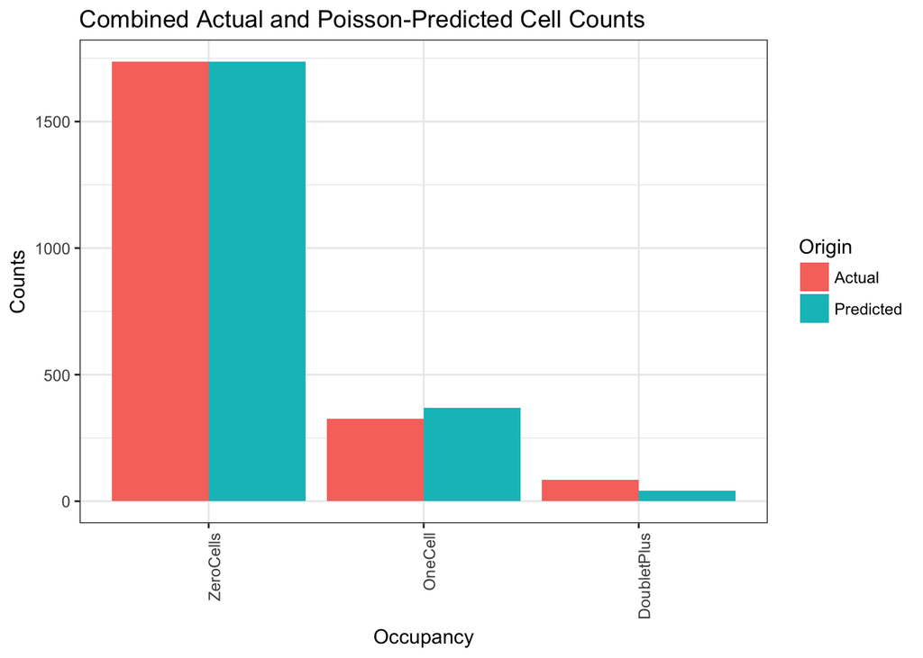

```r
PoissonSummary <- PoissonFull %>% group_by(Origin, Occupancy) %>% summarise(Counts = sum(Counts))

PoissonSummaryPlot <- ggplot(data = PoissonSummary, aes(x = Occupancy, y = Counts, fill = Origin)) +
  geom_bar(stat = "identity", position = position_dodge()) +
  scale_x_discrete(limits=c("ZeroCells", "OneCell", "DoubletPlus")) +
  ggtitle("Combined Actual and Poisson-Predicted Cell Counts") +
  theme_bw() +
  theme(axis.text.x = element_text(angle=90, hjust=1))
PoissonSummaryPlot
```

Save a .jpeg of the Poisson plots

```r
ggsave(PoissonFit, filename = paste0(output,"PoissonFit.jpeg"))
```

```r
ggsave(PoissonSummaryPlot, filename = paste0(output,"PoissonSummaryPlot.jpeg"))
ggsave(CellCountPlot, filename = paste0(output,"CellCountPlot.jpeg"))
```

Save csv’s of cell count distribution data

```r
write.csv(experimentalLambda, file = paste0(output,"poissionEstimateResults.csv"), row.names = F)
write.csv(PoissonFull, file = paste0(output,"PoissonFull.csv"), row.names = F)
write.csv(PoissonSummary, file = paste0(output,"PoissonSummary.csv"), row.names = F)
```

Save the final data frame

```r
write.csv(snowCone4, file = paste0(output,"cellsnowCone.csv"), row.names = F)
```